# Person of Interest — Viewership Analysis

Author

Zahra Eshtiaghi 476679

Published

May 8, 2026

## About the Show

*Person of Interest* is an American science fiction crime drama television series created by Jonathan Nolan and produced in association with *Bad Robot Productions* and *Warner Bros. Television*. The series premiered on CBS on September 22, 2011, and ran for five seasons, concluding on June 21, 2016, with a total of 103 episodes.

The show follows a former CIA agent, **John Reese** (played by Jim Caviezel), who teams up with a reclusive billionaire named **Harold Finch** (Michael Emerson). Together they work in secret using a powerful artificial intelligence surveillance system called *“The Machine”* — which predicts violent crimes before they happen by generating Social Security numbers of individuals who will be involved. Over time the show expanded its cast and mythology, eventually exploring themes of mass surveillance, artificial intelligence, and the ethics of technology.

*Person of Interest* was considered one of the more under-appreciated genre shows of the 2010s, appreciated particularly for the complexity of its storytelling in later seasons.

## Show Poster

[figure not shown]

Person of Interest Poster

## Basic Statistics

```python
import pandas as pd

season_data = {
    'Season': [1, 2, 3, 4, 5],
    'Episodes': [23, 22, 23, 22, 13],
    'Premiere Year': [2011, 2012, 2013, 2014, 2016],
    'Avg Viewers (M)': [13.31, 14.41, 11.83, 9.42, 6.14],
    'Peak Episode Viewers (M)': [15.67, 16.23, 13.17, 10.58, 7.35],
    'Lowest Episode Viewers (M)': [11.57, 12.96, 10.50, 8.18, 4.92]
}

df_seasons = pd.DataFrame(season_data)
df_seasons.index = df_seasons['Season']
df_seasons = df_seasons.drop(columns='Season')

df_seasons.style \
    .set_caption("Table 1: Season-level viewership summary for Person of Interest") \
    .format({'Avg Viewers (M)': '{:.2f}',
             'Peak Episode Viewers (M)': '{:.2f}',
             'Lowest Episode Viewers (M)': '{:.2f}'}) \
    .background_gradient(subset=['Avg Viewers (M)'], cmap='Blues') \
    .set_table_styles([
        {'selector': 'caption', 'props': [('font-size', '13px'), ('font-weight', 'bold')]}
    ])
```

Table 1: Table 1: Season-level viewership summary for Person of Interest

| Season | Episodes | Premiere Year | Avg Viewers (M) | Peak Episode Viewers (M) | Lowest Episode Viewers (M) |
| --- | --- | --- | --- | --- | --- |
| 1 | 23 | 2011 | 13.31 | 15.67 | 11.57 |
| 2 | 22 | 2012 | 14.41 | 16.23 | 12.96 |
| 3 | 23 | 2013 | 11.83 | 13.17 | 10.50 |
| 4 | 22 | 2014 | 9.42 | 10.58 | 8.18 |
| 5 | 13 | 2016 | 6.14 | 7.35 | 4.92 |

**Key facts:**

- The show ran from **2011 to 2016** across 5 seasons
- Total of **103 episodes** aired on CBS
- Peak average season viewership: **14.41 million** (Season 2)
- Final season average: **6.14 million** — a drop of roughly **57% from the peak**
- The all-time highest single episode: *“2πR”* (S2E11) with **16.23 million viewers**

## Viewership Over Time (Episode by Episode)

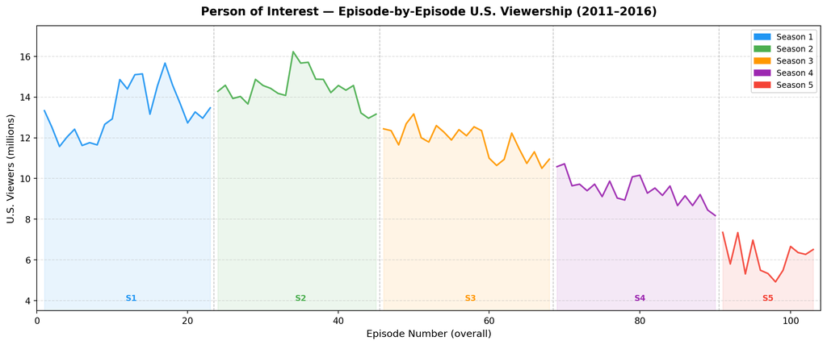

```python
import matplotlib.pyplot as plt
import matplotlib.patches as mpatches
import numpy as np

# All episode viewership data from Wikipedia
seasons_episodes = {
    1: [13.33,12.51,11.57,12.04,12.42,11.62,11.76,11.65,12.66,12.93,
        14.86,14.40,15.10,15.14,13.16,14.56,15.67,14.59,13.69,12.73,13.27,12.96,13.47],
    2: [14.28,14.58,13.93,14.03,13.66,14.87,14.57,14.43,14.18,14.08,
        16.23,15.67,15.71,14.88,14.87,14.22,14.57,14.34,14.57,13.22,12.96,13.16],
    3: [12.44,12.35,11.65,12.69,13.17,12.00,11.79,12.60,12.28,11.89,
        12.40,12.10,12.54,12.35,11.00,10.64,10.94,12.23,11.45,10.74,11.31,10.50,10.95],
    4: [10.58,10.72,9.64,9.72,9.40,9.72,9.11,9.87,9.04,8.94,
        10.08,10.16,9.28,9.53,9.17,9.63,8.67,9.15,8.67,9.21,8.45,8.18],
    5: [7.35,5.80,7.34,5.31,6.97,5.49,5.33,4.92,5.49,6.66,6.36,6.27,6.51]
}

colors = ['#2196F3','#4CAF50','#FF9800','#9C27B0','#F44336']
season_labels = ['Season 1','Season 2','Season 3','Season 4','Season 5']

fig, ax = plt.subplots(figsize=(13, 5.5))

ep_counter = 1
season_boundaries = []

for i, (season, viewers) in enumerate(seasons_episodes.items()):
    x = list(range(ep_counter, ep_counter + len(viewers)))
    ax.plot(x, viewers, color=colors[i], linewidth=1.8, alpha=0.9)
    ax.fill_between(x, viewers, alpha=0.10, color=colors[i])
    season_boundaries.append(ep_counter)
    ep_counter += len(viewers)

for boundary in season_boundaries[1:]:
    ax.axvline(x=boundary - 0.5, color='grey', linestyle='--', linewidth=0.8, alpha=0.5)

# Annotate season labels
starts = [1, 24, 46, 69, 91]
midpoints = [(starts[i] + starts[i+1]) / 2 for i in range(len(starts)-1)]
midpoints.append((starts[-1] + 103) / 2)

for i, mid in enumerate(midpoints):
    ax.text(mid, 4.0, f'S{i+1}', ha='center', fontsize=9, color=colors[i], fontweight='bold')

ax.set_xlabel('Episode Number (overall)', fontsize=11)
ax.set_ylabel('U.S. Viewers (millions)', fontsize=11)
ax.set_title('Person of Interest — Episode-by-Episode U.S. Viewership (2011–2016)',
             fontsize=13, fontweight='bold', pad=12)
ax.set_xlim(0, 104)
ax.set_ylim(3.5, 17.5)
ax.grid(axis='y', linestyle='--', alpha=0.4)

patches = [mpatches.Patch(color=colors[i], label=season_labels[i]) for i in range(5)]
ax.legend(handles=patches, loc='upper right', framealpha=0.85, fontsize=9)

plt.tight_layout()
plt.savefig('poi_viewership_episodes.png', dpi=150, bbox_inches='tight')
plt.show()
```

## Average Viewership per Season

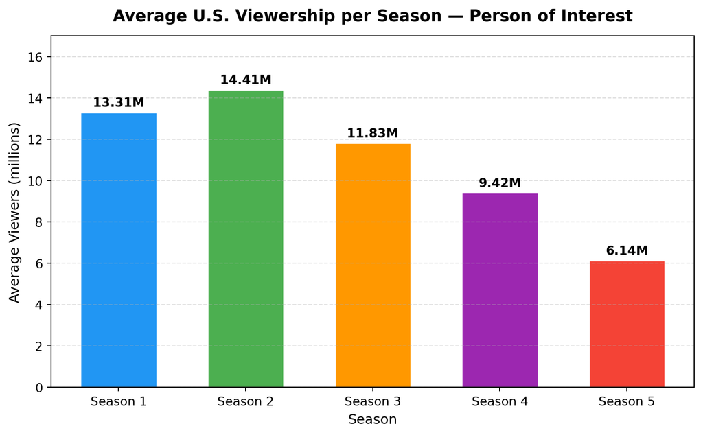

```python
avg_viewers = [13.31, 14.41, 11.83, 9.42, 6.14]
seasons = [1, 2, 3, 4, 5]

fig, ax = plt.subplots(figsize=(8, 5))

bars = ax.bar(seasons, avg_viewers, color=colors, edgecolor='white', linewidth=1.2, width=0.6)

for bar, val in zip(bars, avg_viewers):
    ax.text(bar.get_x() + bar.get_width()/2, bar.get_height() + 0.15,
            f'{val:.2f}M', ha='center', va='bottom', fontsize=10, fontweight='bold')

ax.set_xlabel('Season', fontsize=11)
ax.set_ylabel('Average Viewers (millions)', fontsize=11)
ax.set_title('Average U.S. Viewership per Season — Person of Interest',
             fontsize=13, fontweight='bold', pad=12)
ax.set_xticks(seasons)
ax.set_xticklabels([f'Season {s}' for s in seasons])
ax.set_ylim(0, 17)
ax.grid(axis='y', linestyle='--', alpha=0.4)

plt.tight_layout()
plt.savefig('poi_viewership_avg.png', dpi=150, bbox_inches='tight')
plt.show()
```

## Season-to-Season Change in Viewership

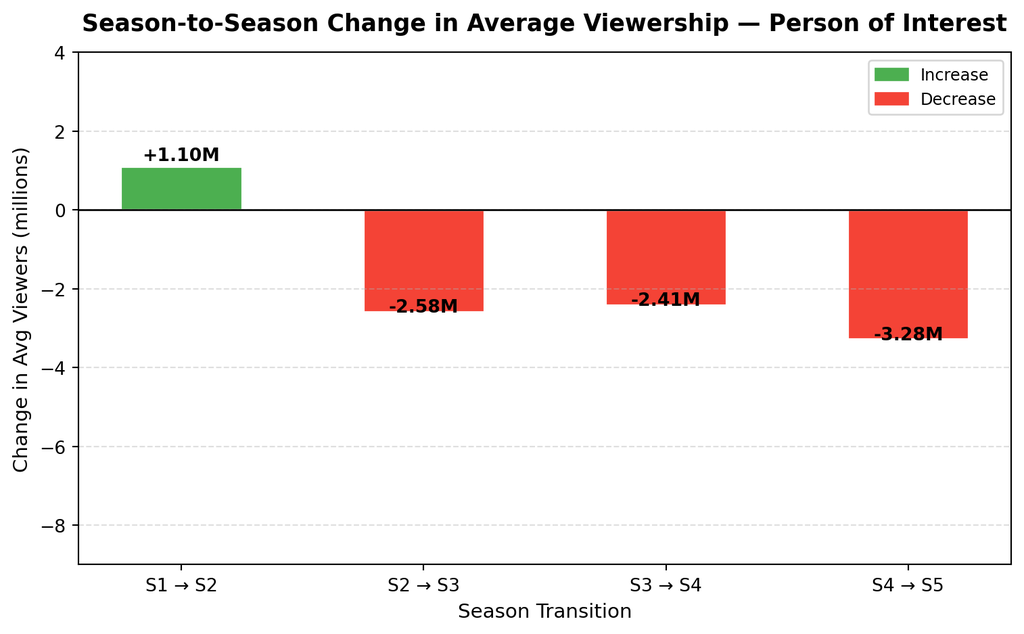

```python
changes = [round(avg_viewers[i] - avg_viewers[i-1], 2) for i in range(1, len(avg_viewers))]
change_labels = ['S1 → S2', 'S2 → S3', 'S3 → S4', 'S4 → S5']
bar_colors = ['#4CAF50' if c > 0 else '#F44336' for c in changes]

fig, ax = plt.subplots(figsize=(8, 5))

bars = ax.bar(change_labels, changes, color=bar_colors, edgecolor='white', linewidth=1.2, width=0.5)

for bar, val in zip(bars, changes):
    ypos = val + 0.05 if val > 0 else val - 0.12
    ax.text(bar.get_x() + bar.get_width()/2, ypos,
            f'{val:+.2f}M', ha='center', va='bottom', fontsize=10, fontweight='bold')

ax.axhline(0, color='black', linewidth=1)
ax.set_xlabel('Season Transition', fontsize=11)
ax.set_ylabel('Change in Avg Viewers (millions)', fontsize=11)
ax.set_title('Season-to-Season Change in Average Viewership — Person of Interest',
             fontsize=13, fontweight='bold', pad=12)
ax.set_ylim(-9, 4)
ax.grid(axis='y', linestyle='--', alpha=0.4)

green_patch = mpatches.Patch(color='#4CAF50', label='Increase')
red_patch = mpatches.Patch(color='#F44336', label='Decrease')
ax.legend(handles=[green_patch, red_patch], fontsize=9)

plt.tight_layout()
plt.savefig('poi_viewership_change.png', dpi=150, bbox_inches='tight')
plt.show()
```

## Analysis of Viewership Trends

*Person of Interest* had a fairly clear arc across its five seasons: a strong start, a peak in the second season, and a steady decline through to its finale.

Season 1 averaged **13.31 million viewers**, which was already solid for a new CBS drama. The show picked up momentum heading into Season 2, which became its best-performing season at an average of **14.41 million** — an increase of `+1.10 million` from the debut season. The midseason episode *“2πR”* (S2E11) represents the all-time peak of the series at **16.23 million viewers**.

Season 5 was the most dramatic in terms of viewership loss. With only 13 episodes and a summer burn-off schedule starting in May 2016, average viewership collapsed to **6.14 million** — a drop of `-3.28 million` from Season 4. The lowest point of the entire run came in Season 5, Episode 8 (*“Reassortment”*) with just **4.92 million viewers**, compared to the Season 2 peak of 16.23 million — a total decline of **`-11.31 million`** between the show’s best and worst individual episodes.

## Data Source

All viewership data sourced from [Wikipedia — List of Person of Interest episodes](https://en.wikipedia.org/wiki/List_of_Person_of_Interest_episodes), originally measured by Nielsen Media Research.

> ⚠️ *Note: Sections of this report, specifically parts of the introduction paragraph and the data visualisation code, were assisted by an AI tool (Claude) in accordance with the assignmet AI use policy.*